# Assignment2

10878862

26/04/2022

# Prepare for R markdown

Here, let’s turn off the warning and message for later chunks, because during model fitting there are lots of messages about fitting errors, so to make it clear and readable, I set them both as false to ignore this information. It is worth noticing that I have handled all the warnings to make sure all the processing is correct, and I would mention some warning information when necessary.

# Load all packages

```r
library(ISLR2)
library(tidyverse)
library(GGally)
library(leaps)
library(car) # This is for load VIF function to
library(effects)
library(caret)
library(splines)
library(gam)
library(broom)
```

# Regression question

## Read in dataset

Load, go through and check our data (to make sure there is no observation containing NaN which might cause unexepcted problems)

```r
RegressionData <- Boston[,c(5,7,8,12,13)]
str(RegressionData)
```

```
## 'data.frame':    506 obs. of  5 variables:
##  $ nox  : num  0.538 0.469 0.469 0.458 0.458 0.458 0.524 0.524 0.524 0.524 ...
##  $ age  : num  65.2 78.9 61.1 45.8 54.2 58.7 66.6 96.1 100 85.9 ...
##  $ dis  : num  4.09 4.97 4.97 6.06 6.06 ...
##  $ lstat: num  4.98 9.14 4.03 2.94 5.33 ...
##  $ medv : num  24 21.6 34.7 33.4 36.2 28.7 22.9 27.1 16.5 18.9 ...
```

```r
missingobservation <- RegressionData[apply(RegressionData, 1, function(x) sum(is.na(x))) == 1]

sum(missingobservation)
```

```
## [1] 0
```

Luckily, there is no missing data.

## Construct Baseline model

It is suggested we started from linear regression model because of the accessibility to interpretation and the rule of parsimony.

First, we can use correlation test to capture the linear relationship between predictors and dependent (response) variables. Although we won’t make any decision based on this result due to the lack of reliable excluding criterion, at least we can get a intuition of our data, which is beneficial for us to make subjective choices later when necessary.

### Choice of Baseline Model Variables

Here, we can use `ggpairs` function from `GGally` packages, which present the scatter plot, density plot and correlation coefficient directly and clearly for all pairs of variables.

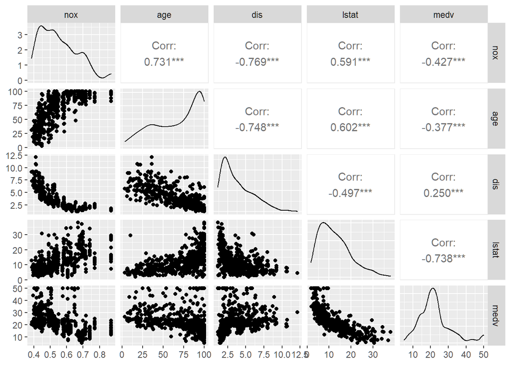

```r
ggpairs(RegressionData)
```

Through this plot, we could find that almost all the predictive variables are correlated with predicted variable - *nox*, however, the predicted variables are also correlated with each other and they are not normal-distributed, which might cause multilinearity and affect the accuracy of linear model.

Keep this information in mind and continue to construct our linear regression model.

### Subset Selection

Now, let’s conduct **subset selection** with function `regsubsets`, which return the best variables suggested to be used for n-varaible (n from 1 to 4 in this case) model, notably, “best” here is quantified using RSS. We can calculate the various fitting indices with `summary` function, and store them into *reg_summary*.

```r
regfit_full = regsubsets(nox~., data = RegressionData, nvmax = 4)
reg_summary <- summary(regfit_full)
```

Besides using RSS, we could also check other parameters such as adjusted R2 , Cp, and BIC to compare these models.

```r
reg_summary$rsq
```

```
## [1] 0.5917150 0.6506535 0.6799426 0.6820447
```

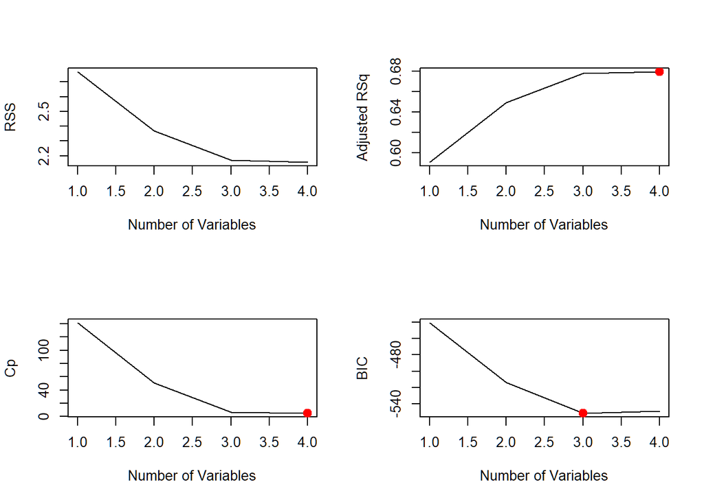

```r
# Set up a 2x2 grid so we can look at 4 plots at once
par(mfrow = c(2,2))
plot(reg_summary$rss, xlab = "Number of Variables", ylab = "RSS", type = "l")
plot(reg_summary$adjr2, xlab = "Number of Variables", ylab = "Adjusted RSq", type = "l")

# We will now plot a red dot to indicate the model with the largest adjusted R^2 statistic.

adj_r2_max = which.max(reg_summary$adjr2) # 11

points(adj_r2_max, reg_summary$adjr2[adj_r2_max], col ="red", cex = 2, pch = 20)

# We'll do the same for C_p and BIC.
plot(reg_summary$cp, xlab = "Number of Variables", ylab = "Cp", type = "l")
cp_min = which.min(reg_summary$cp) # 10
points(cp_min, reg_summary$cp[cp_min], col = "red", cex = 2, pch = 20)

plot(reg_summary$bic, xlab = "Number of Variables", ylab = "BIC", type = "l")
bic_min = which.min(reg_summary$bic) # 6
points(bic_min, reg_summary$bic[bic_min], col = "red", cex = 2, pch = 20)
```

Also, we could draw pictures to show which variable should be included in each model direcly.

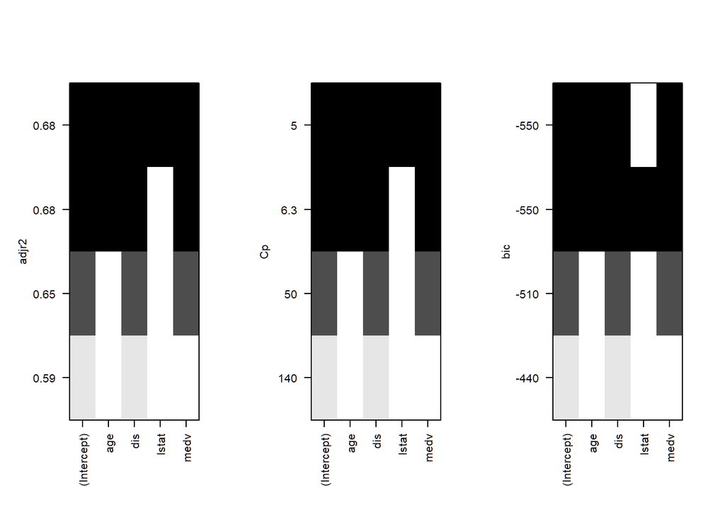

```r
par(mfrow = c(1,3))
plot(regfit_full, scale = "adjr2")

plot(regfit_full, scale = "Cp")

plot(regfit_full, scale = "bic")
```

Although **BIC** value suggested that the 3-variable model (*lstat* was excluded) was the best, the **Cp** and **RSq** suggested 4-variable model is still slightly better than 3-variable model. Because there are only 4 variables, it’s not tricky to compare them. Therefore, we included everything in our model here and use a full 4-variable model as a starting point for our later analysis.

### Assumption test 1

Now, we started to test the assumption of this model to see if there are some problems existing.

```r
lm.fit = lm(nox~., data = RegressionData)
vif(lm.fit)
```

```
##      age      dis    lstat     medv
## 2.702579 2.344189 3.091143 2.284361
```

According to the VIF, we should have an intuitive feeling that multicollinearity is not a noticeable issue for this model.

## Model Improvement with Non-linear Approach

As previous scatter plot suggested, some predictor variables might has non-linear relationship with *nox*, here I work on each input variable one by one to see if using a non-linear method will improve the model.

### Fitting Age

First, let’s plot the residual of age in this multilinear model.

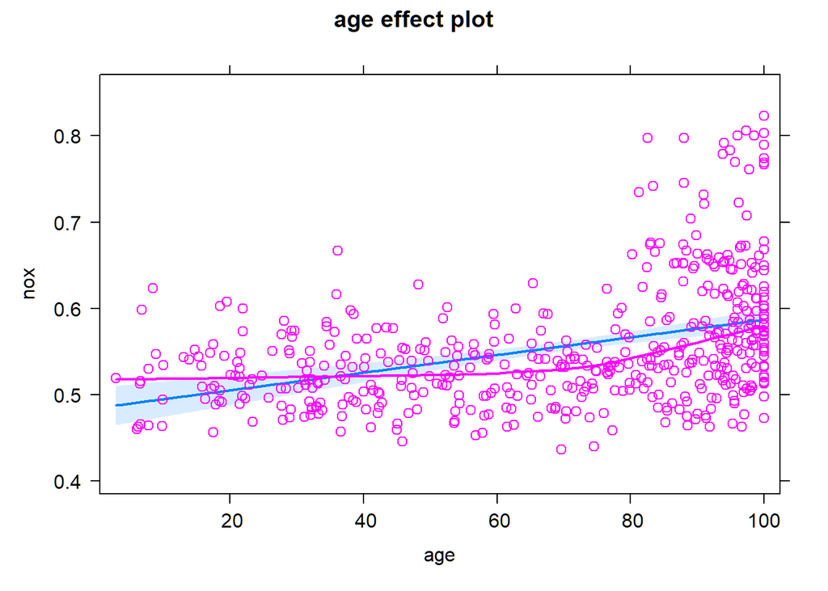

```r
plot(effect("age", mod = lm.fit, partial.residuals = TRUE))
```

The blue line apparently differs from the pink line, which suggests that our model failed to capture the correct shape. Thus, we need to consider non-linear relationship between *age* and *nox*.

#### 1.1.1 Refit *age* with Polynomial

Here, we use `train()` function within the loop to calculate the MSE value for each degree of polynomial model.

Noticeably, for all the cross-validation below, I always use LOOCV cross-validation because it is more stable and with lower variance, and it shows a replicable value for every run.

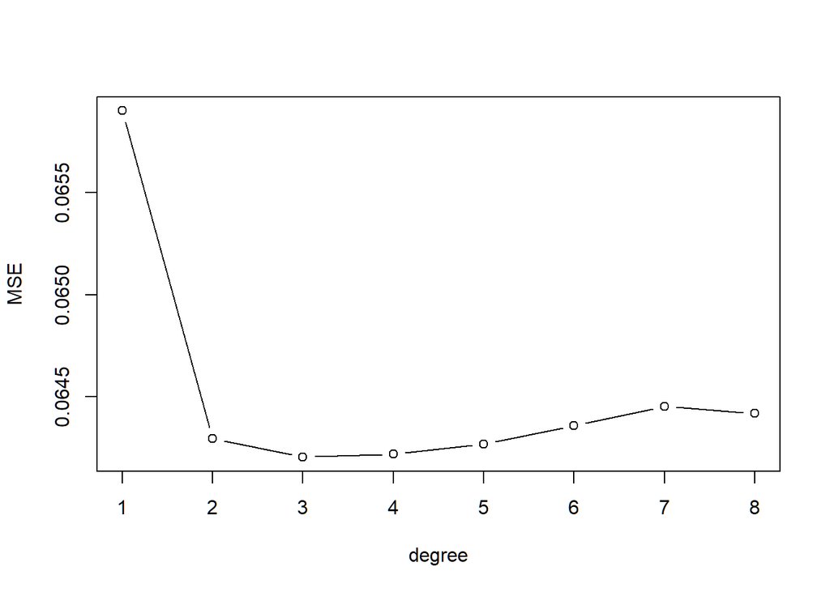

```r
set.seed(1234)


train_control <- trainControl(method="LOOCV")

fit.age.1 <- train(nox ~ poly(age,1) + dis + lstat + medv,
                      data = RegressionData,
                      method = "lm", trControl = train_control)
fit.age.2 <- train(nox ~ poly(age,2) + dis + lstat + medv,
                      data = RegressionData,
                      method = "lm", trControl = train_control)
fit.age.3 <- train(nox ~ poly(age,3) + dis + lstat + medv,
                      data = RegressionData,
                      method = "lm", trControl = train_control)
fit.age.4 <- train(nox ~ poly(age,4) + dis + lstat + medv,
                      data = RegressionData,
                      method = "lm", trControl = train_control)
fit.age.5 <- train(nox ~ poly(age,5) + dis + lstat + medv,
                      data = RegressionData,
                      method = "lm", trControl = train_control)
fit.age.6 <- train(nox ~ poly(age,6) + dis + lstat + medv,
                      data = RegressionData,
                      method = "lm", trControl = train_control)
fit.age.7 <- train(nox ~ poly(age,7) + dis + lstat + medv,
                      data = RegressionData,
                      method = "lm", trControl = train_control)
fit.age.8 <- train(nox ~ poly(age,8) + dis + lstat + medv,
                      data = RegressionData,
                      method = "lm", trControl = train_control)
MSE <- rep(0,8)
MSE[1] <- fit.age.1$results$RMSE
MSE[2] <- fit.age.2$results$RMSE
MSE[3] <- fit.age.3$results$RMSE
MSE[4] <- fit.age.4$results$RMSE
MSE[5] <- fit.age.5$results$RMSE
MSE[6] <- fit.age.6$results$RMSE
MSE[7] <- fit.age.7$results$RMSE
MSE[8] <- fit.age.8$results$RMSE

plot(1:8, MSE, type = "b", xlab = "degree")
```

```r
which.min(MSE)
```

```
## [1] 3
```

```r
MSE[which.min(MSE)]
```

```
## [1] 0.06420508
```

The result suggested that the third-degree polynomial with the smallest MSE of 0.0642 is the best.

Here, we refit the model with a third-degree polynomial and plot the effect again.

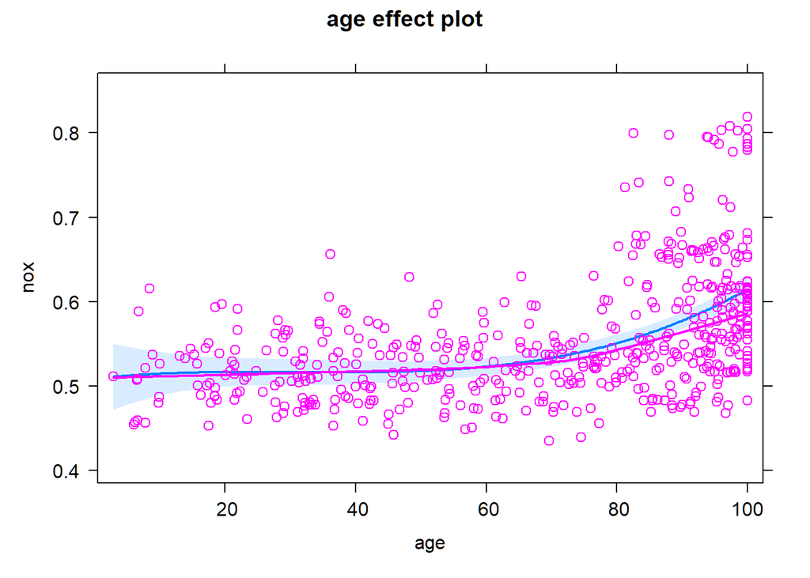

```r
lm.fit.age3 = lm(nox ~ poly(age,3) + dis + lstat + medv,
                      data = RegressionData)

plot(effect("age", mod = lm.fit.age3, partial.residuals = TRUE))
```

Now the blue line is much closer to the pink line.

Except the polynomial model, we could also try to use spline to fit this model.

#### 1.1.2 Refit *age* with Basis Spline

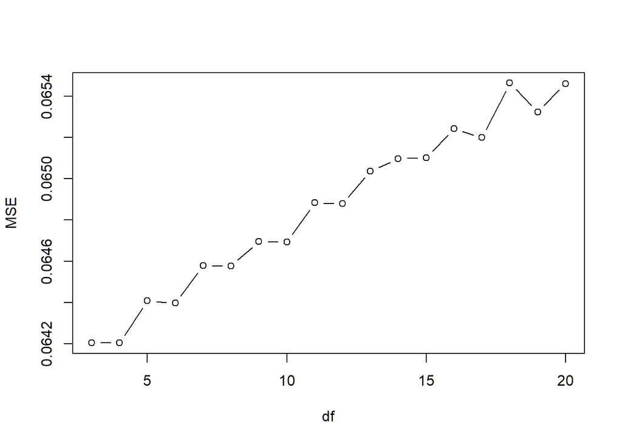

```r
MSE <- rep(0,18)
for (i in 3:20){
  Data <- RegressionData
  Data$agespline <- bs(RegressionData$age, df = i)
  fit <- train(nox ~ agespline + dis + lstat + medv,
               data = Data,
               method = 'lm',
               trControl=train_control)
  MSE[i-2] <- fit$results$RMSE
}
plot(3:20, MSE, type='b', xlab = 'df')
```

```r
dfn <- which.min(MSE) + 2
dfn
```

```
## [1] 4
```

```r
MSE[which.min(MSE)]
```

```
## [1] 0.06420433
```

The resultant plot showed that the 4th degrees of freedom produces the lowest MSE, which is 0.0642. Here, we refit age with 4th degree of basis spline and plot the residual.

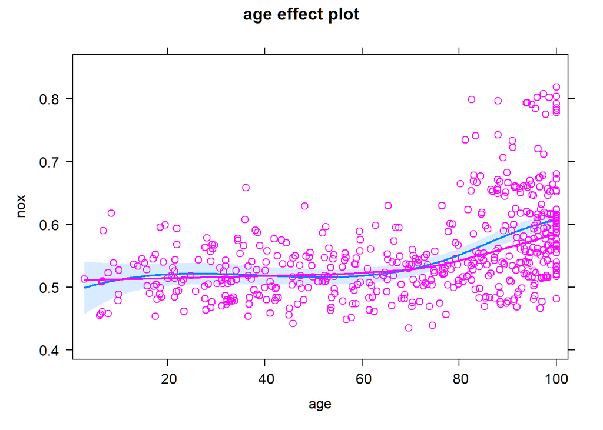

```r
  lm.bs.age3 <- lm(nox ~ bs(age,df = 4) + dis + lstat + medv,
               data = RegressionData)
  plot(effect("age", mod = lm.bs.age3, partial.residuals = TRUE))
```

The MSE for this is not different from third polynomial fitting. Let’s continue to try the natural spline.

#### 1.1.3 Refit *age* with Natural Spline

Test age with natural splines.

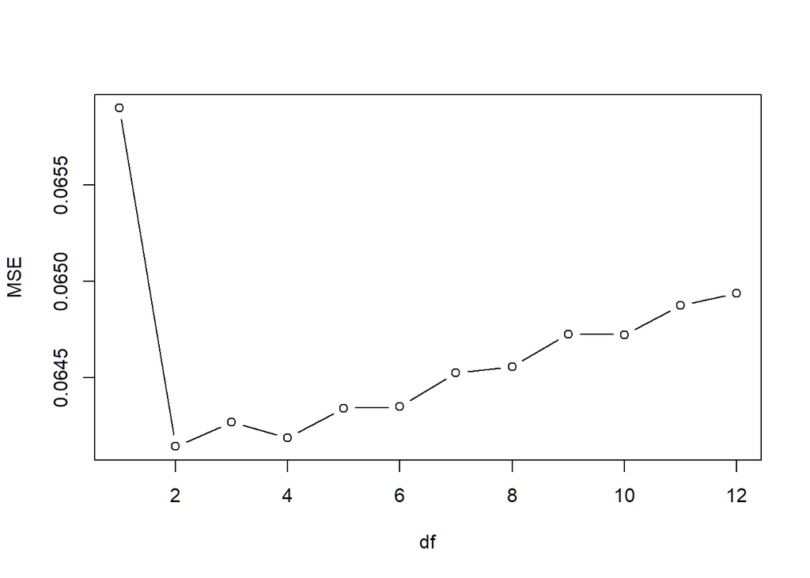

```r
MSE <- rep(0,12)
for (i in 1:12){
  Data <- RegressionData
  Data$agens <- ns(RegressionData$age, df = i)
  fit <- train(nox ~ agens + dis + lstat + medv,
               data = Data,
               method = 'lm',
               trControl=train_control)
  MSE[i] <- fit$results$RMSE
}

plot(1:12, MSE, type='b', xlab = 'df')
```

```r
which.min(MSE)
```

```
## [1] 2
```

```r
MSE[which.min(MSE)]
```

```
## [1] 0.06414247
```

The smallest MSE = 0.0641, which is from when df = 2.

Here, we refit age with 2 degree natural spline to inspect the pattern of residual.

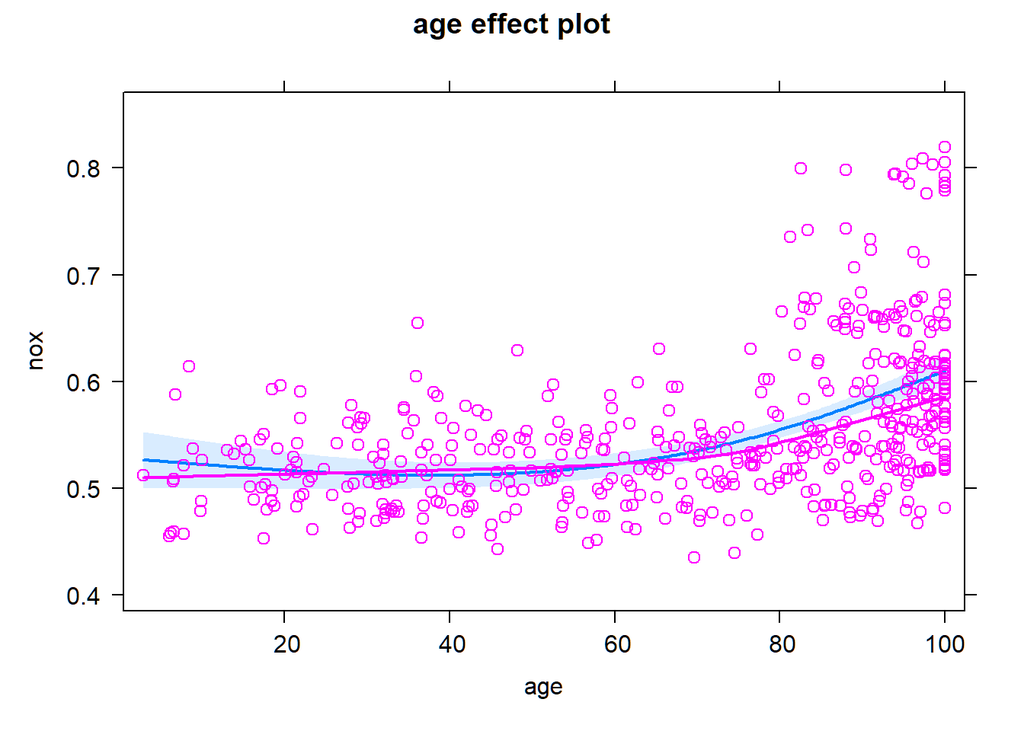

```r
lm.ns.age2 <- lm(nox ~ ns(age,df = 2) + dis + lstat + medv,
               data = RegressionData)
plot(effect("age", mod = lm.ns.age2, partial.residuals = TRUE))
```

According to these four plots, we could see that the later three are all better than the first plot.

Although the natural spline has the smallest MSE, it’s not that distinguishable and the residual of the cubic model almost overlaps with the fitted pink line (especially for the left-bottom part). I decided to put the third polynomial fitted age into the model.

As I have determined *age*, now, let’s continue to do the same thing to *dis*, *lstat*, and *medv*.

#### Plot redisual for *dis*

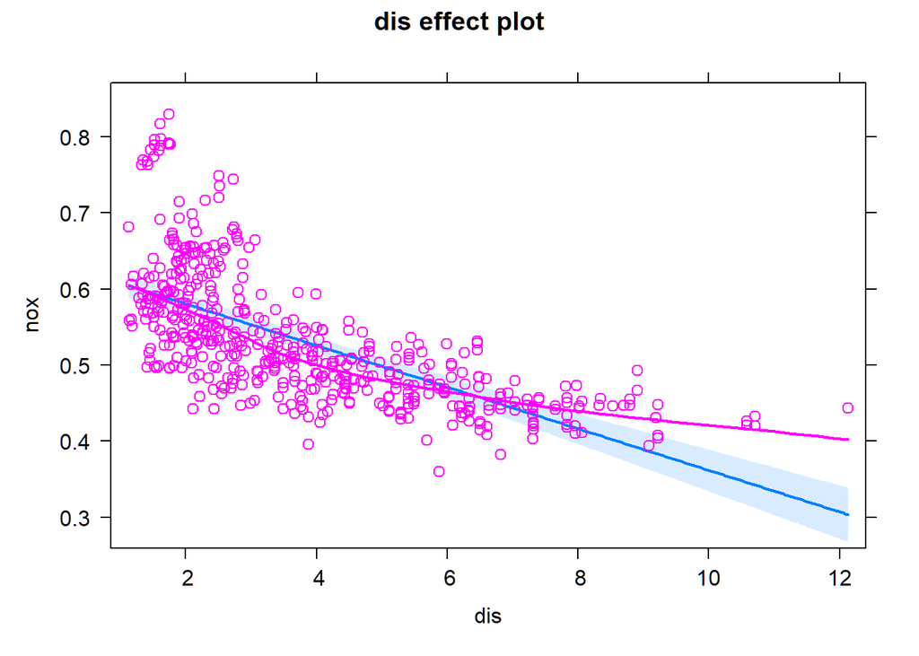

```r
fit.dis <- lm(nox ~ poly(age,3) + dis + lstat + medv,
                      data = RegressionData,
                      method = "lm")
plot(effect("dis", mod = fit.dis, partial.residuals = TRUE))
```

This plot shows terrible nonlinear problems.

### Fitting *dis*

Because all the process is almost the same as the above processing, here I omit the narrative and just show the script and results.

#### 1.2.1 Refit *dis* with Polynomial

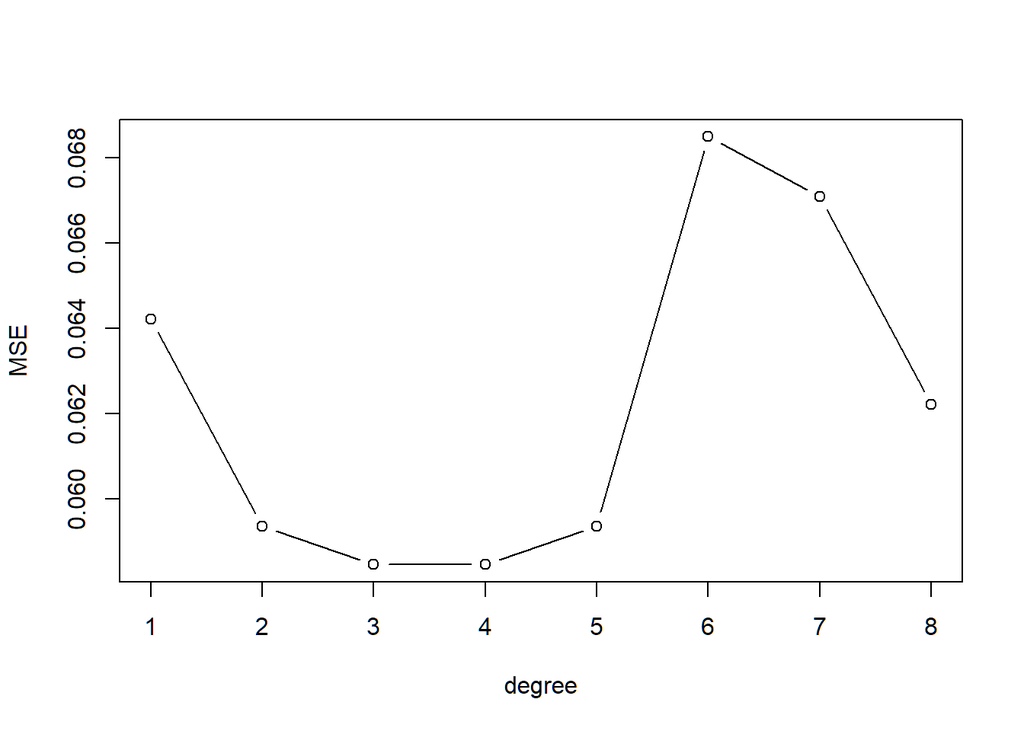

```r
set.seed(1234)

fit.dis.1 <- train(nox ~ poly(age,3) + poly(dis,1) + lstat + medv,
                      data = RegressionData,
                      method = "lm", trControl = train_control)
fit.dis.2 <- train(nox ~ poly(age,3) + poly(dis,2) + lstat + medv,
                      data = RegressionData,
                      method = "lm", trControl = train_control)
fit.dis.3 <- train(nox ~ poly(age,3) + poly(dis,3) + lstat + medv,
                      data = RegressionData,
                      method = "lm", trControl = train_control)
fit.dis.4 <- train(nox ~ poly(age,3) + poly(dis,4) + lstat + medv,
                      data = RegressionData,
                      method = "lm", trControl = train_control)
fit.dis.5 <- train(nox ~ poly(age,3) + poly(dis,5) + lstat + medv,
                      data = RegressionData,
                      method = "lm", trControl = train_control)
fit.dis.6 <- train(nox ~ poly(age,3) + poly(dis,6) + lstat + medv,
                      data = RegressionData,
                      method = "lm", trControl = train_control)
fit.dis.7 <- train(nox ~ poly(age,3) + poly(dis,7) + lstat + medv,
                      data = RegressionData,
                      method = "lm", trControl = train_control)
fit.dis.8 <- train(nox ~ poly(age,3) + poly(dis,8) + lstat + medv,
                      data = RegressionData,
                      method = "lm", trControl = train_control)
MSE <- rep(0,8)
MSE[1] <- fit.dis.1$results$RMSE
MSE[2] <- fit.dis.2$results$RMSE
MSE[3] <- fit.dis.3$results$RMSE
MSE[4] <- fit.dis.4$results$RMSE
MSE[5] <- fit.dis.5$results$RMSE
MSE[6] <- fit.dis.6$results$RMSE
MSE[7] <- fit.dis.7$results$RMSE
MSE[8] <- fit.dis.8$results$RMSE

plot(1:8, MSE, type = "b", xlab = "degree")
```

```r
which.min(MSE)
```

```
## [1] 4
```

```r
MSE[which.min(MSE)]
```

```
## [1] 0.05845656
```

The 4th polynomial fitting is the best for *dis* with MSE = 0.0585, third polynomial fitting is also good.

#### 1.2.2 Refit *dis* with Basis Spline

The degree should beyond 3, so we set i from 3.

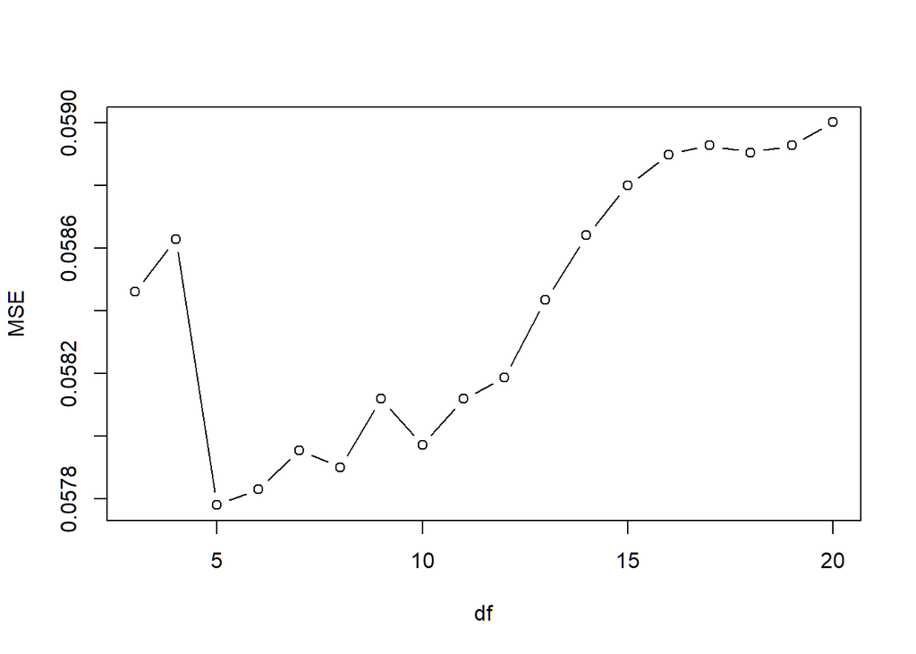

```r
MSE <- rep(0,18)
for (i in 3:20){
  Data <- RegressionData
  Data$disspline <- bs(RegressionData$dis, df = i)
  fit <- train(nox ~ poly(age,3) + disspline + lstat + medv,
               data = Data,
               method = 'lm',
               trControl=train_control)
  MSE[i-2] <- fit$results$RMSE
}
plot(3:20, MSE, type='b', xlab = 'df')
```

```r
dfn <- which.min(MSE) + 2
dfn
```

```
## [1] 5
```

```r
MSE[which.min(MSE)]
```

```
## [1] 0.05777915
```

Basis spine with 5 df is the best and the MSE is 0.05778.

#### 1.2.3 Refit *dis* with Natural Spine model

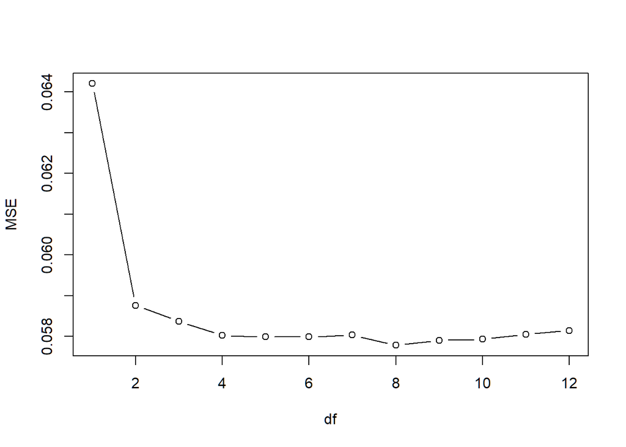

```r
MSE <- rep(0,12)
for (i in 1:12){
  Data <- RegressionData
  Data$disns <- ns(RegressionData$dis, df = i)
  fit <- train(nox ~ poly(age,3) + disns + lstat + medv,
               data = Data,
               method = 'lm',
               trControl=train_control)
  MSE[i] <- fit$results$RMSE
}

plot(1:12, MSE, type='b', xlab = 'df')
```

```r
which.min(MSE)
```

```
## [1] 8
```

```r
MSE[which.min(MSE)]
```

```
## [1] 0.05778422
```

For natural spline, df=8 has the smallest MSE, which is 0.05778, and from df = 4 to df = 8 are almost the same.

Here, let’s compare the fitted residual among different fitting methods with well performance.

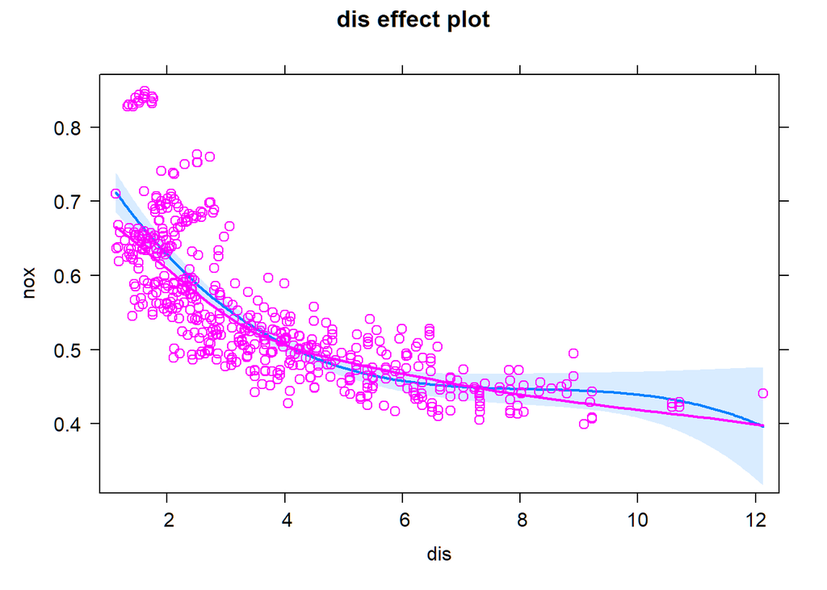

```r
lm.fit.dis3 = lm(nox ~ poly(age,3) + poly(dis,3) + lstat + medv,
                      data = RegressionData)
lm.fit.dis4 = lm(nox ~ poly(age,3) + poly(dis,4) + lstat + medv,
                      data = RegressionData)
lm.bs.dis5 <- lm(nox ~ poly(age,3) + bs(dis,5) + lstat + medv,
               data = RegressionData)
lm.ns.dis4 <- lm(nox ~ poly(age,3) + ns(dis,df=4) + lstat + medv,
               data = RegressionData)
lm.ns.dis8 <- lm(nox ~ poly(age,3) + ns(dis,df=8) + lstat + medv,
               data = RegressionData)

plot(effect("dis", mod = lm.fit.dis3, partial.residuals = TRUE))
```

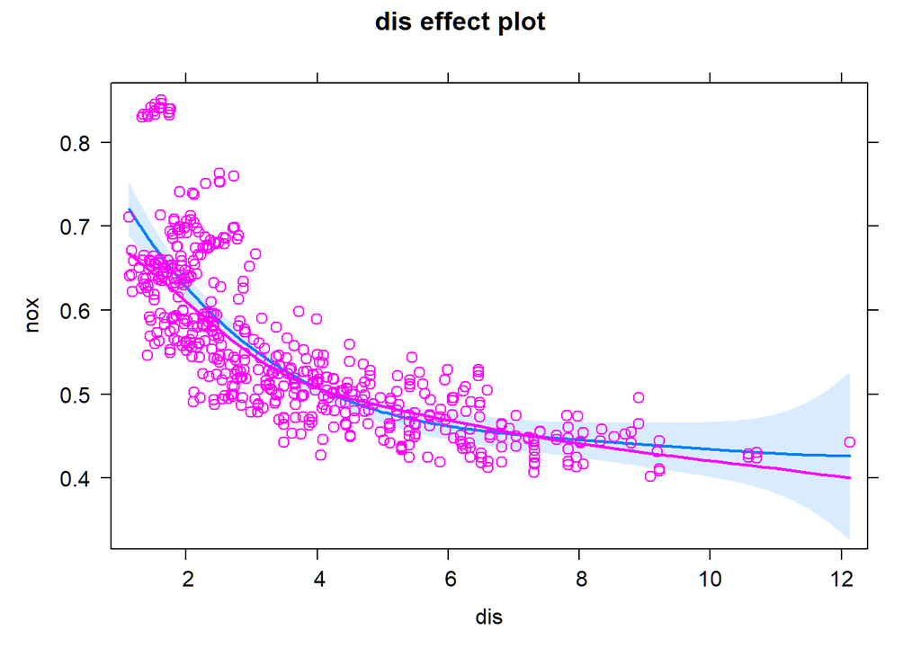

```r
plot(effect("dis", mod = lm.fit.dis4, partial.residuals = TRUE))
```

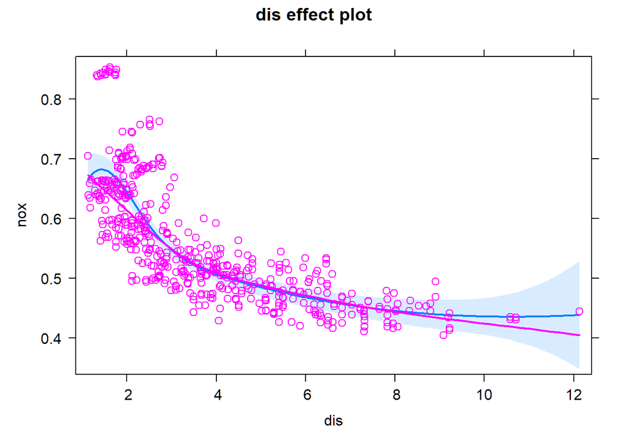

```r
plot(effect("dis", mod = lm.bs.dis5, partial.residuals = TRUE))
```

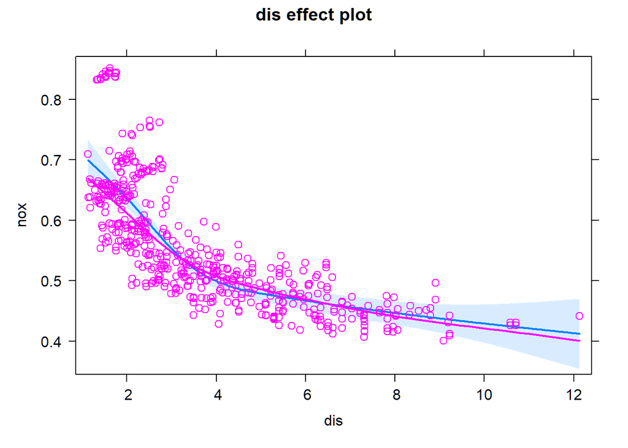

```r
plot(effect("dis", mod = lm.ns.dis4, partial.residuals = TRUE))
```

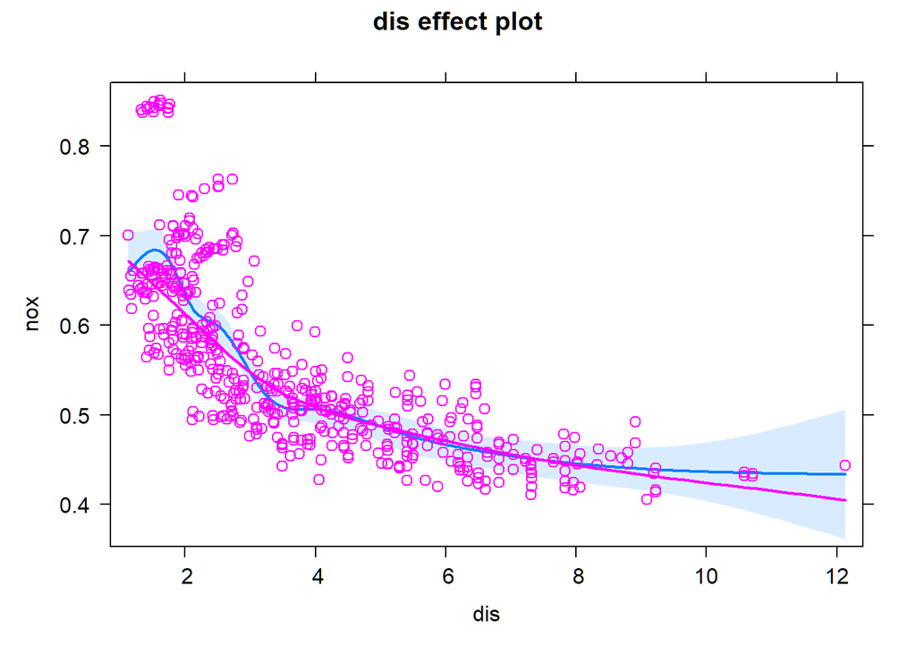

```r
plot(effect("dis", mod = lm.ns.dis8, partial.residuals = TRUE))
```

Here, it seems like the shape of residual of natural spline model with 4th-degree performance best as well as with the least wiggles.

### Fitting *lstat*

#### 1.3.1 Refit *lstat* with Polynomial

## polynomial model

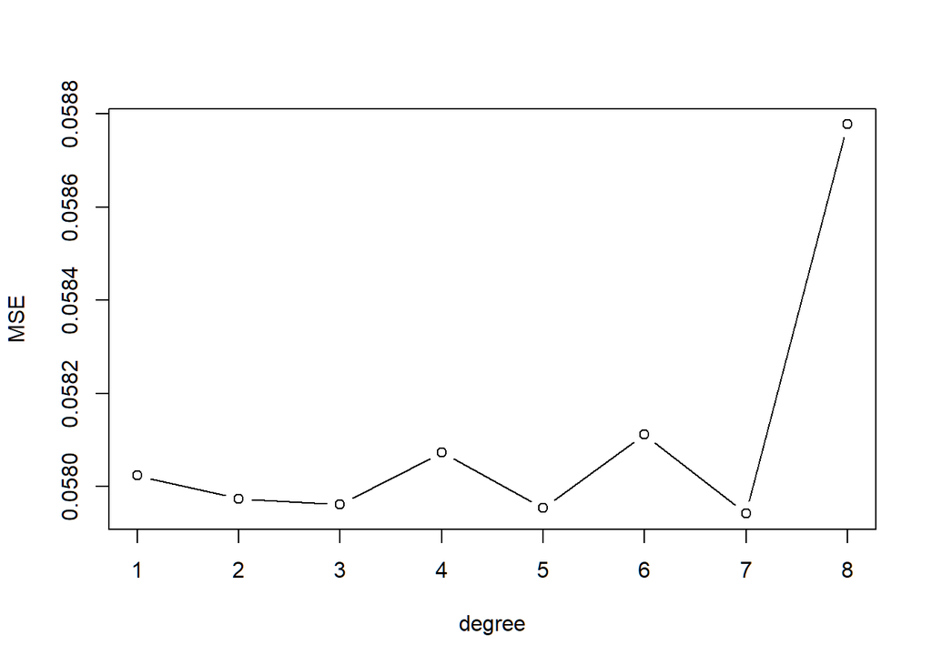

```r
fit.lstat.1 <- train(nox ~ poly(age,3) + ns(dis,df = 4) + poly(lstat,1) + medv,
                      data = RegressionData,
                      method = "lm", trControl = train_control)
fit.lstat.2 <- train(nox ~ poly(age,3) + ns(dis,4) + poly(lstat,2) + medv,
                      data = RegressionData,
                      method = "lm", trControl = train_control)
fit.lstat.3 <- train(nox ~ poly(age,3) + ns(dis,4) + poly(lstat,3) + medv,
                      data = RegressionData,
                      method = "lm", trControl = train_control)
fit.lstat.4 <- train(nox ~ poly(age,3) + ns(dis,4) + poly(lstat,4) + medv,
                      data = RegressionData,
                      method = "lm", trControl = train_control)
fit.lstat.5 <- train(nox ~ poly(age,3) + ns(dis,4) + poly(lstat,5) + medv,
                      data = RegressionData,
                      method = "lm", trControl = train_control)
fit.lstat.6 <- train(nox ~ poly(age,3) + ns(dis,4) + poly(lstat,6) + medv,
                      data = RegressionData,
                      method = "lm", trControl = train_control)
fit.lstat.7 <- train(nox ~ poly(age,3) + ns(dis,4) + poly(lstat,7) + medv,
                      data = RegressionData,
                      method = "lm", trControl = train_control)
fit.lstat.8 <- train(nox ~ poly(age,3) + ns(dis,4) + poly(lstat,8) + medv,
                      data = RegressionData,
                      method = "lm", trControl = train_control)
MSE <- rep(0,8)
MSE[1] <- fit.lstat.1$results$RMSE
MSE[2] <- fit.lstat.2$results$RMSE
MSE[3] <- fit.lstat.3$results$RMSE
MSE[4] <- fit.lstat.4$results$RMSE
MSE[5] <- fit.lstat.5$results$RMSE
MSE[6] <- fit.lstat.6$results$RMSE
MSE[7] <- fit.lstat.7$results$RMSE
MSE[8] <- fit.lstat.8$results$RMSE

plot(1:8, MSE, type = "b", xlab = "degree")
```

```r
which.min(MSE)
```

```
## [1] 7
```

```r
MSE[which.min(MSE)]
```

```
## [1] 0.05794206
```

Here, 2, 3, 5, 7 are almost the same, so let’s plot the residual shapes of these models. On the grounds of parsimony. Let’s compare th 2, 3, and 7.

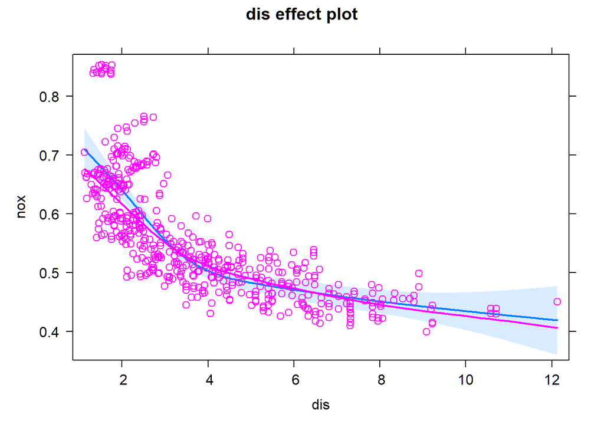

```r
lm.fit.lstat2 = lm(nox ~ poly(age,3) + ns(dis,4) + poly(lstat,2) + medv,
                 data = RegressionData)
lm.fit.lstat3 = lm(nox ~ poly(age,3) + ns(dis,4) + poly(lstat,3) + medv,
                 data = RegressionData)
lm.fit.lstat7 = lm(nox ~ poly(age,3) + ns(dis,4) + poly(lstat,7) + medv,
                 data = RegressionData)

plot(effect("dis", mod = lm.fit.lstat2, partial.residuals = TRUE))
```

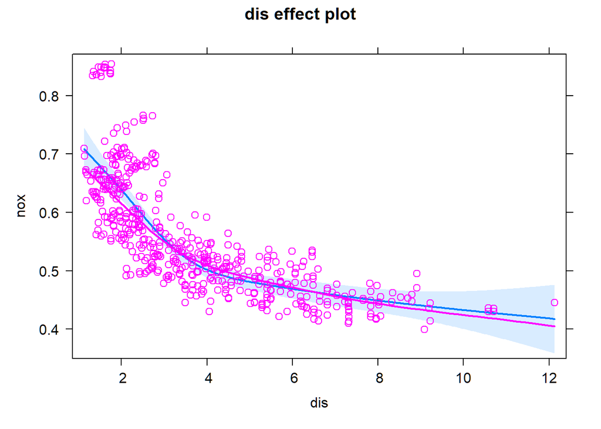

```r
plot(effect("dis", mod = lm.fit.lstat3, partial.residuals = TRUE))
```

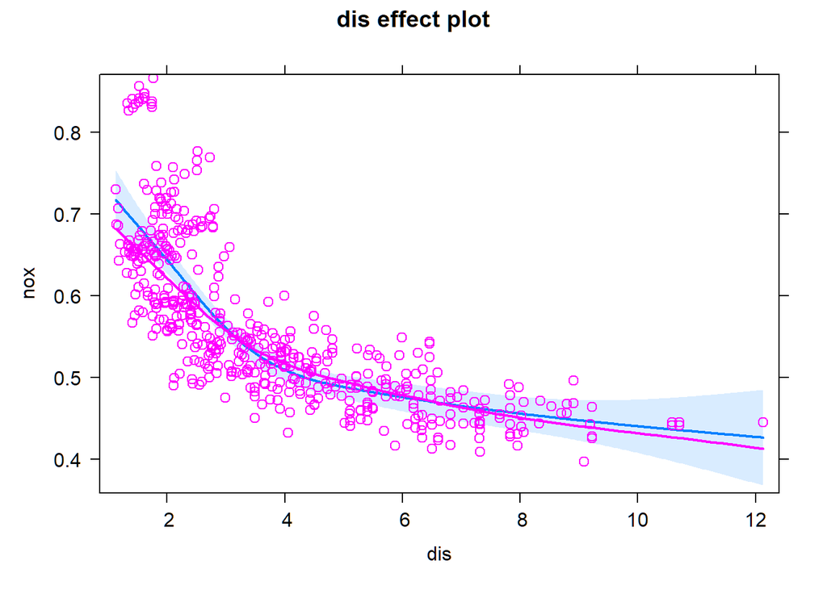

```r
plot(effect("dis", mod = lm.fit.lstat7, partial.residuals = TRUE))
```

```r
MSE[2]
```

```
## [1] 0.05797407
```

There’s no significant difference and the second polynomial still has a relatively small MSE = 0.0580.

#### 1.3.2 Refit *lstatbs* with Basis Spline

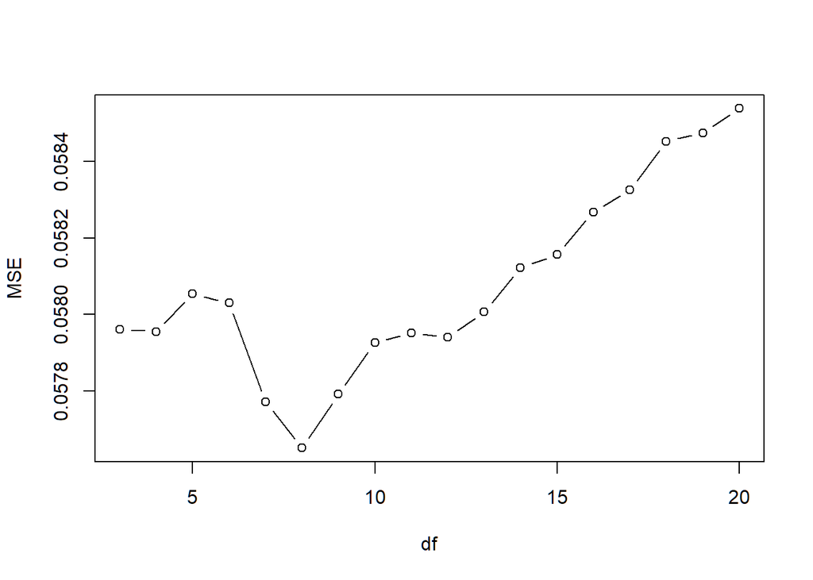

```r
MSE <- rep(0,18)
for (i in 3:20){
  Data <- RegressionData
  Data$lstatbs <- bs(RegressionData$lstat, df = i)
  fit <- train(nox ~ poly(age,3) + ns(dis,4) + lstatbs + medv,
               data = Data,
               method = 'lm',
               trControl=train_control)
  MSE[i-2] <- fit$results$RMSE
}
plot(3:20, MSE, type='b', xlab = 'df')
```

```r
dfn <- which.min(MSE) + 2
dfn
```

```
## [1] 8
```

```r
MSE[which.min(MSE)]
```

```
## [1] 0.05765122
```

Here, basis spline with df = 8 has the lowest MSE (0.0577), which is better than polynomial fit.

#### 1.3.3 Refit *lstatbs* with Natural Spline

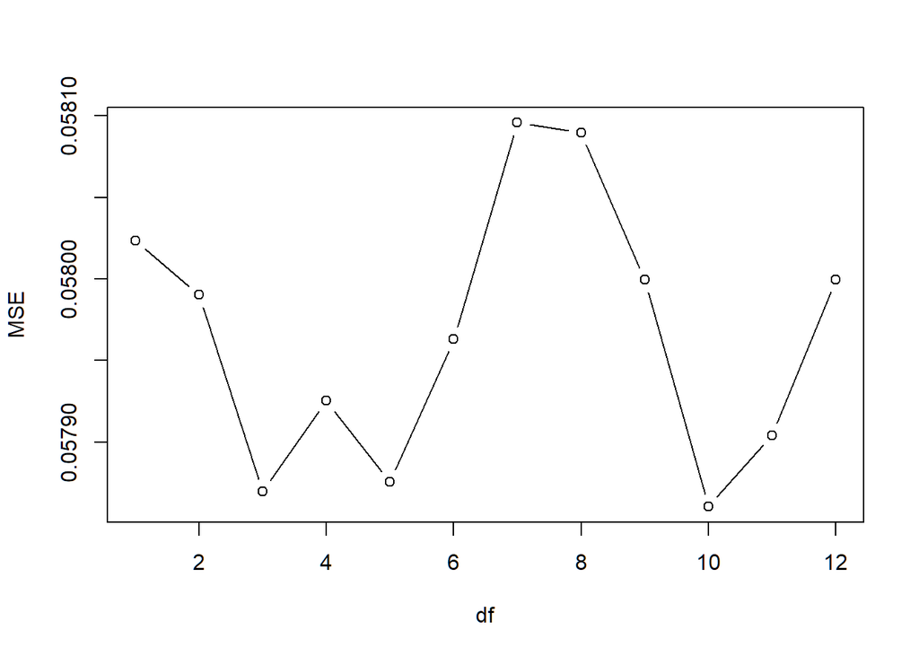

```r
MSE <- rep(0,12)
for (i in 1:12){
  Data <- RegressionData
  Data$lstatns <- ns(RegressionData$lstat, df = i)
  fit <- train(nox ~ poly(age,3) + ns(dis,4) + lstatns + medv,
               data = Data,
               method = 'lm',
               trControl=train_control)
  MSE[i] <- fit$results$RMSE
}

plot(1:12, MSE, type='b', xlab = 'df')
```

```r
which.min(MSE)
```

```
## [1] 10
```

```r
MSE[which.min(MSE)]
```

```
## [1] 0.05786041
```

Natural spline with 10 degree is the best among this but has lager MSE than 8 degree basis spine.

Now let’s compare between this three fitting methods for *lstat*.

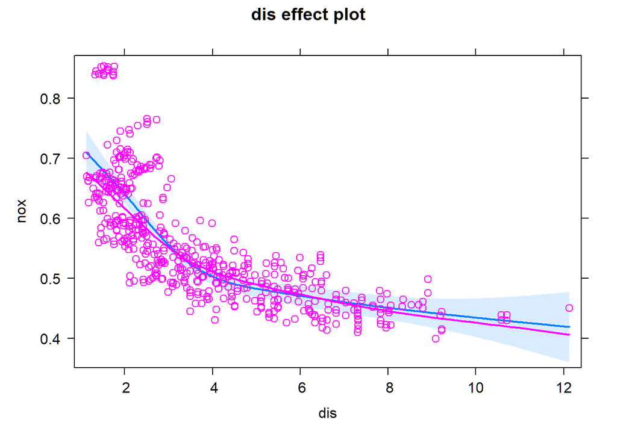

```r
lm.lstat2 = lm(nox ~ poly(age,3) + ns(dis,4) + poly(lstat,2) + medv,
                 data = RegressionData)
lm.bs.lstat8 = lm(nox ~ poly(age,3) + ns(dis,4) + bs(lstat,8) + medv,
                 data = RegressionData)
lm.ns.lstat10 = lm(nox ~ poly(age,3) + ns(dis,4) + ns(lstat,10) + medv,
                 data = RegressionData)
plot(effect("dis", mod = lm.lstat2, partial.residuals = TRUE))
```

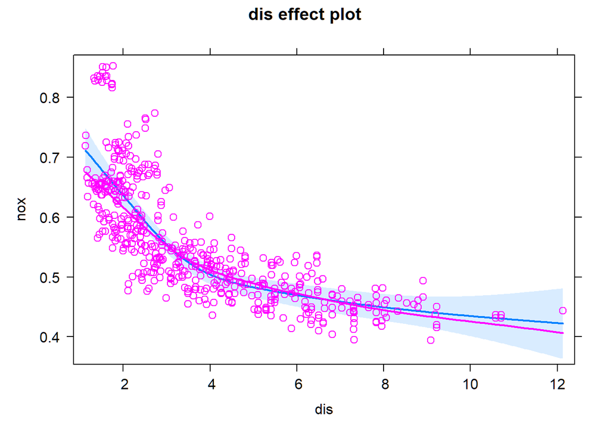

```r
plot(effect("dis", mod = lm.bs.lstat8, partial.residuals = TRUE))
```

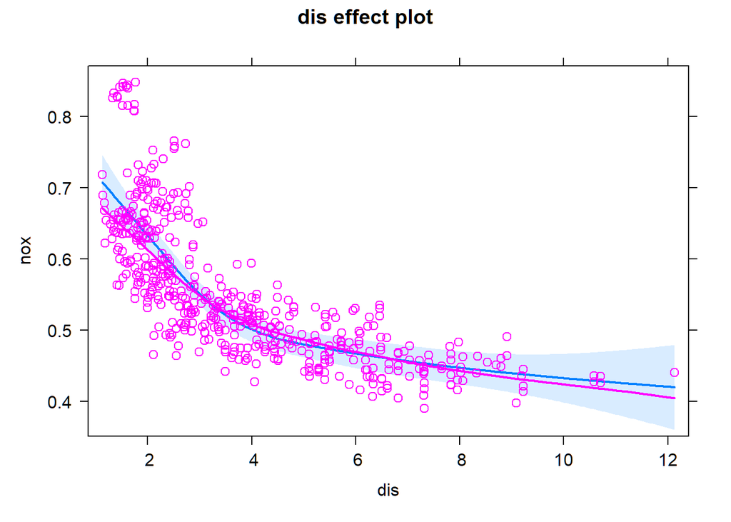

```r
plot(effect("dis", mod = lm.ns.lstat10, partial.residuals = TRUE))
```

The plots are all good, so we choose bs with 8 df with smallest MSE = 0.0577.

### Fitting *medv*

#### 1.4.1 Refit *medv* with Polynomial

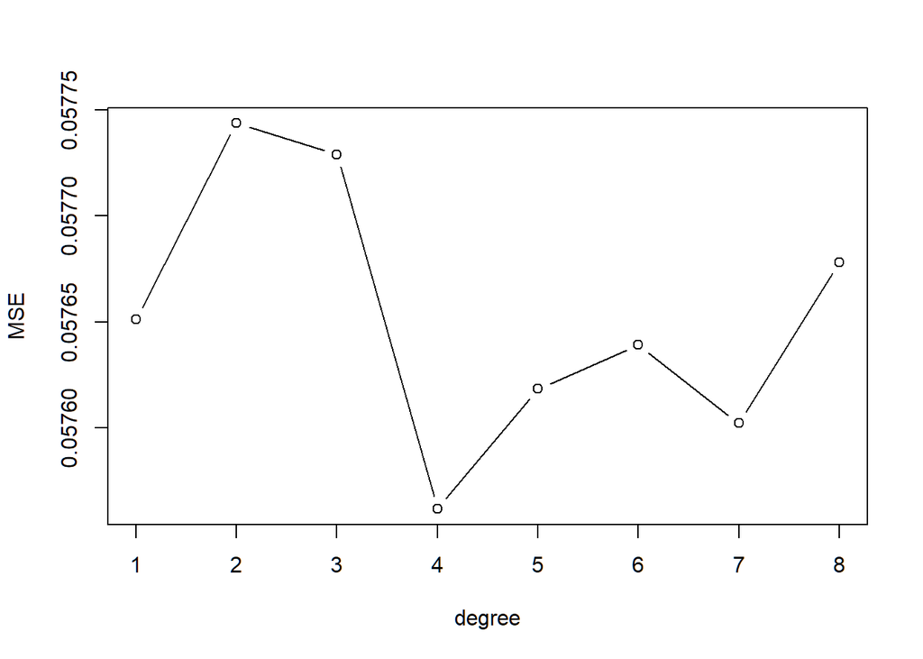

```r
fit.medv.1 <- train(nox ~ poly(age,3) + ns(dis,4) + bs(lstat,8)
                   + poly(medv,1),
                      data = RegressionData,
                      method = "lm", trControl = train_control)
fit.medv.2 <- train(nox ~ poly(age,3) + ns(dis,4) + bs(lstat,8)
                   + poly(medv,2),
                      data = RegressionData,
                      method = "lm", trControl = train_control)
fit.medv.3 <- train(nox ~ poly(age,3) + ns(dis,4) + bs(lstat,8)
                   + poly(medv,3),
                      data = RegressionData,
                      method = "lm", trControl = train_control)
fit.medv.4 <- train(nox ~ poly(age,3) + ns(dis,4) + bs(lstat,8)
                   + poly(medv,4),
                      data = RegressionData,
                      method = "lm", trControl = train_control)
fit.medv.5 <- train(nox ~ poly(age,3) + ns(dis,4) + bs(lstat,8)
                   + poly(medv,5),
                      data = RegressionData,
                      method = "lm", trControl = train_control)
fit.medv.6 <- train(nox ~ poly(age,3) + ns(dis,4) + bs(lstat,8)
                   + poly(medv,6),
                      data = RegressionData,
                      method = "lm", trControl = train_control)
fit.medv.7 <- train(nox ~ poly(age,3) + ns(dis,4) + bs(lstat,8)
                   + poly(medv,7),
                      data = RegressionData,
                      method = "lm", trControl = train_control)
fit.medv.8 <- train(nox ~ poly(age,3) + ns(dis,4) + bs(lstat,8)
                   + poly(medv,8),
                      data = RegressionData,
                      method = "lm", trControl = train_control)
MSE <- rep(0,8)
MSE[1] <- fit.medv.1$results$RMSE
MSE[2] <- fit.medv.2$results$RMSE
MSE[3] <- fit.medv.3$results$RMSE
MSE[4] <- fit.medv.4$results$RMSE
MSE[5] <- fit.medv.5$results$RMSE
MSE[6] <- fit.medv.6$results$RMSE
MSE[7] <- fit.medv.7$results$RMSE
MSE[8] <- fit.medv.8$results$RMSE

plot(1:8, MSE, type = "b", xlab = "degree")
```

```r
which.min(MSE)
```

```
## [1] 4
```

```r
MSE[which.min(MSE)]
```

```
## [1] 0.05756186
```

Here, 4th polynomial has smallest MSE, which is 0.0576.

#### 1.4.2 Refit *medv* with Basis Spline.

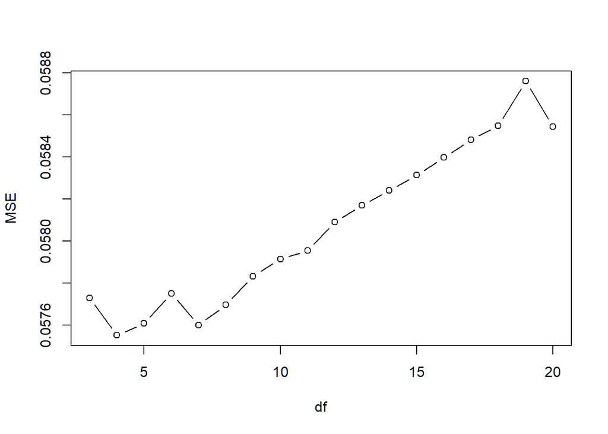

```r
MSE <- rep(0,18)
for (i in 3:20){
  Data <- RegressionData
  Data$medvbs <- bs(RegressionData$medv, df = i)
  fit <- train(nox ~ poly(age,3) + ns(dis,4) + bs(lstat,8) + medvbs,
               data = Data,
               method = 'lm',
               trControl=train_control)
  MSE[i-2] <- fit$results$RMSE
}
plot(3:20, MSE, type='b', xlab = 'df')
```

```r
dfn <- which.min(MSE) + 2
dfn
```

```
## [1] 4
```

```r
MSE[which.min(MSE)]
```

```
## [1] 0.05755134
```

Here, when df = 4, the MSE is the smallest (0.0576).